# Practical_Lab 4

**Practical Lab 4 - Polynomial Regression and Evaluation using R-Squared, MAPE and MAE**

**Problem Framing:**

-The problem involves building a univariate polynomial regression model to predict the risk of diabetes progression based on a single independent variable, which is the Body Mass Index (BMI) feature in the Scikit-Learn Diabetes dataset.

-**Independent Variable (Feature):** BMI

-**Dependent Variable (Target):** Diabetes Progression

-**Objective:** Develop a predictive model to assist physicians in identifying patients at risk of diabetes progression using BMI as a screening tool.

**Goal:**

-**Build a polynomial regression model that provides an effective screening tool for predicting diabetes progression based on BMI.**

-**Assess the model's performance using R-squared, MAPE, and MAE metrics**

[Scikit-Learn datasets](https://scikit-learn.org/stable/modules/generated/sklearn.datasets.load_diabetes.html#sklearn.datasets.load_diabetes)

```python
from sklearn.datasets import load_diabetes
# Load diabetes dataset
diabetes = load_diabetes()
# Access different attributes
data = diabetes.data
target = diabetes.target
feature_names = diabetes.feature_names
```

**EDA:** Describing the data, explore it, and provide insights about it.

```
Basic Statistics of the Dataset:
                age           sex           bmi            bp            s1  \
count  4.420000e+02  4.420000e+02  4.420000e+02  4.420000e+02  4.420000e+02
mean  -2.511817e-19  1.230790e-17 -2.245564e-16 -4.797570e-17 -1.381499e-17
std    4.761905e-02  4.761905e-02  4.761905e-02  4.761905e-02  4.761905e-02
min   -1.072256e-01 -4.464164e-02 -9.027530e-02 -1.123988e-01 -1.267807e-01
25%   -3.729927e-02 -4.464164e-02 -3.422907e-02 -3.665608e-02 -3.424784e-02
50%    5.383060e-03 -4.464164e-02 -7.283766e-03 -5.670422e-03 -4.320866e-03
75%    3.807591e-02  5.068012e-02  3.124802e-02  3.564379e-02  2.835801e-02
max    1.107267e-01  5.068012e-02  1.705552e-01  1.320436e-01  1.539137e-01

                 s2            s3            s4            s5            s6  \
count  4.420000e+02  4.420000e+02  4.420000e+02  4.420000e+02  4.420000e+02
mean   3.918434e-17 -5.777179e-18 -9.042540e-18  9.293722e-17  1.130318e-17
std    4.761905e-02  4.761905e-02  4.761905e-02  4.761905e-02  4.761905e-02
min   -1.156131e-01 -1.023071e-01 -7.639450e-02 -1.260971e-01 -1.377672e-01
25%   -3.035840e-02 -3.511716e-02 -3.949338e-02 -3.324559e-02 -3.317903e-02
50%   -3.819065e-03 -6.584468e-03 -2.592262e-03 -1.947171e-03 -1.077698e-03
75%    2.984439e-02  2.931150e-02  3.430886e-02  3.243232e-02  2.791705e-02
max    1.987880e-01  1.811791e-01  1.852344e-01  1.335973e-01  1.356118e-01

           Target
count  442.000000
mean   152.133484
std     77.093005
min     25.000000
25%     87.000000
50%    140.500000
75%    211.500000
max    346.000000
```

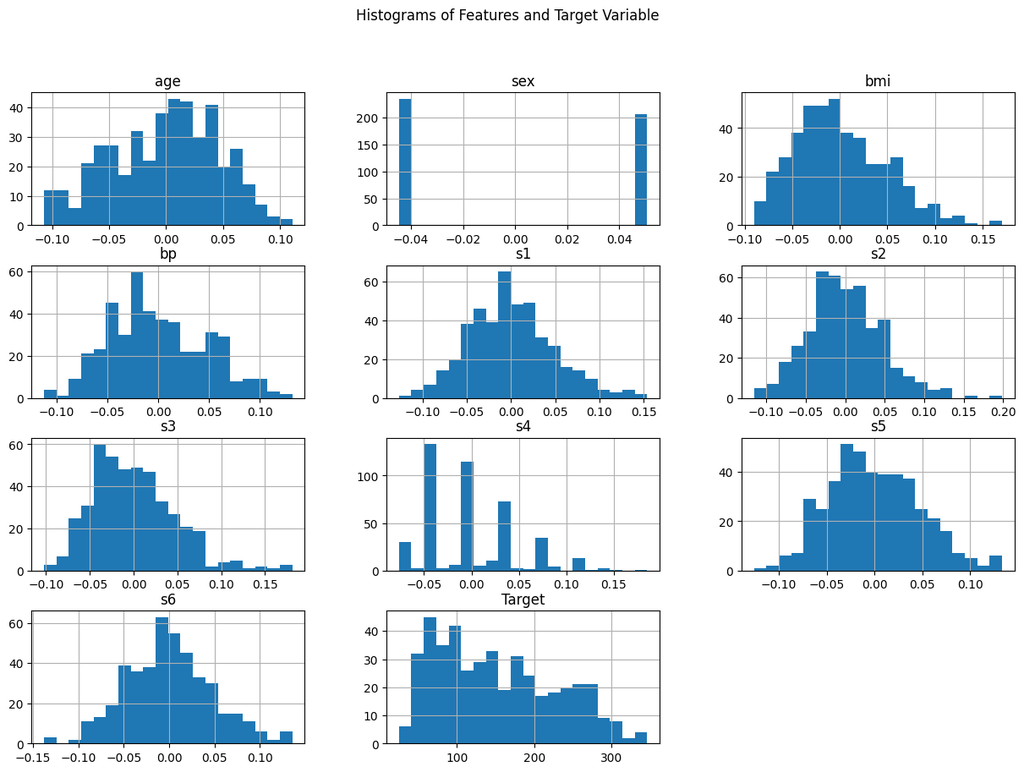

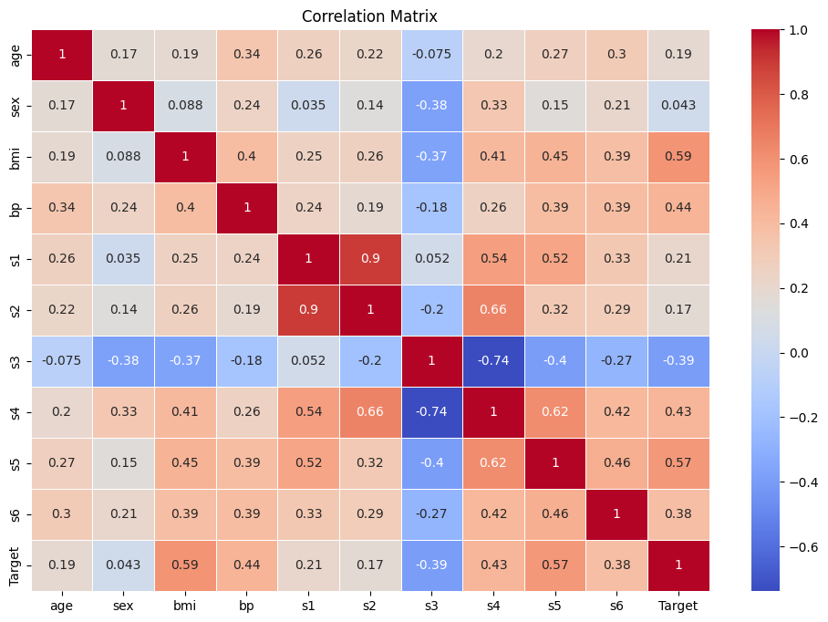

```python
import numpy as np
import pandas as pd
import matplotlib.pyplot as plt
import seaborn as sns
from sklearn.datasets import load_diabetes
diabetes = load_diabetes()
# DataFrame for easy analysis
df = pd.DataFrame(data=diabetes.data, columns=diabetes.feature_names)
df['Target'] = diabetes.target
# Display basic statistics of the dataset
print("Basic Statistics of the Dataset:")
print(df.describe())
# Generate histograms for each feature and the target variable
df.hist(bins=20, figsize=(15, 10))
plt.suptitle("Histograms of Features and Target Variable")
plt.show()
# Create a correlation matrix to explore relationships between variables
correlation_matrix = df.corr()
# Visualize the correlation matrix using a heatmap
plt.figure(figsize=(12, 8))
sns.heatmap(correlation_matrix, annot=True, cmap="coolwarm", linewidths=0.5)
plt.title("Correlation Matrix")
plt.show()
```

**Cleaning the data, and explaining reason for reader**

```
Missing Values Information:
age       0
sex       0
bmi       0
bp        0
s1        0
s2        0
s3        0
s4        0
s5        0
s6        0
Target    0
dtype: int64
Number of Duplicates: 0

Cleaned Data Summary:
Number of Samples: 442
Number of Features: 10
```

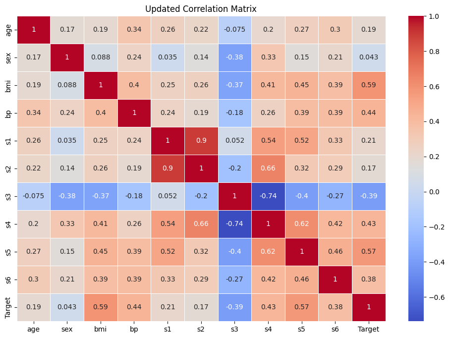

```python
from sklearn.model_selection import train_test_split
# Display information about missing values
print("Missing Values Information:")
print(df.isnull().sum())
# Check for duplicates and drop them if present
print("Number of Duplicates:", df.duplicated().sum())
df = df.drop_duplicates()
# Split the data into features (X) and target variable (y)
X = df.drop('Target', axis=1)
y = df['Target']
# Split the data into training and testing sets
X_train, X_test, y_train, y_test = train_test_split(X, y, test_size=0.2, random_state=42)
# Display the cleaned data summary
print("\nCleaned Data Summary:")
print("Number of Samples:", len(df))
print("Number of Features:", X.shape[1])
# Display the updated correlation matrix
correlation_matrix = df.corr()
plt.figure(figsize=(12, 8))
sns.heatmap(correlation_matrix, annot=True, cmap="coolwarm", linewidths=0.5)
plt.title("Updated Correlation Matrix")
plt.show()
```

1. Missing Values: Checking for missing values is crucial to ensure that the dataset is complete.
2. Duplicates: Duplicates can affect the model's performance and should be removed.
3. Data Splitting:The dataset is split into features (X) and the target variable (y). Additionally, the data is further split into training and testing sets using the train_test_split function. This step is essential for model training and evaluation
4. Cleaned Data Summary:Displaying a summary of the cleaned data provides information about the number of samples and features after the cleaning process

**Splitting the dataset to a train (70%), validation (15%) and test (15%) sets**

```python
# Split the data into training (70%) and temporary data (30%)
X_train, X_temp, y_train, y_temp = train_test_split(X, y, test_size=0.3, random_state=42)
# Split the temporary data into validation (50%) and test (50%)
X_val, X_test, y_val, y_test = train_test_split(X_temp, y_temp, test_size=0.5, random_state=42)
# Display the shapes of the resulting sets
print("Training set shape:", X_train.shape, y_train.shape)
print("Validation set shape:", X_val.shape, y_val.shape)
print("Test set shape:", X_test.shape, y_test.shape)
```

```
Training set shape: (309, 10) (309,)
Validation set shape: (66, 10) (66,)
Test set shape: (67, 10) (67,)
```

**Polynomial Regression on the BMI feature**

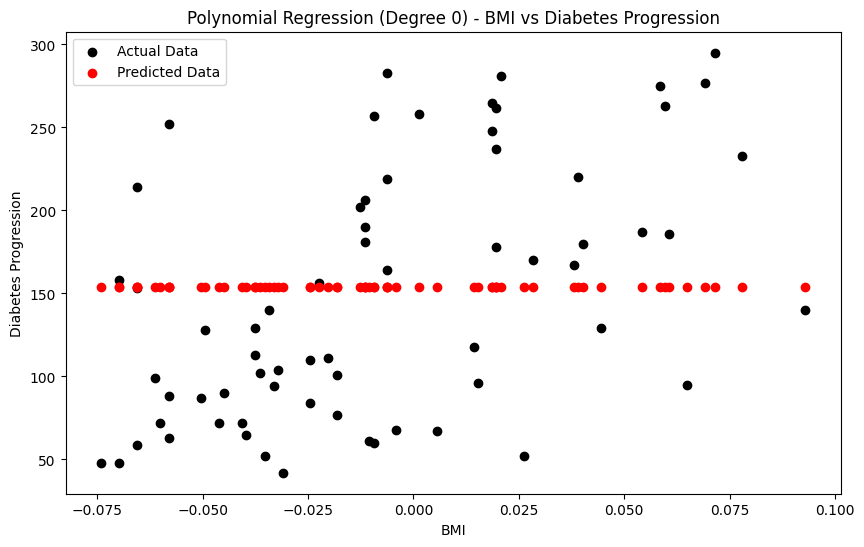

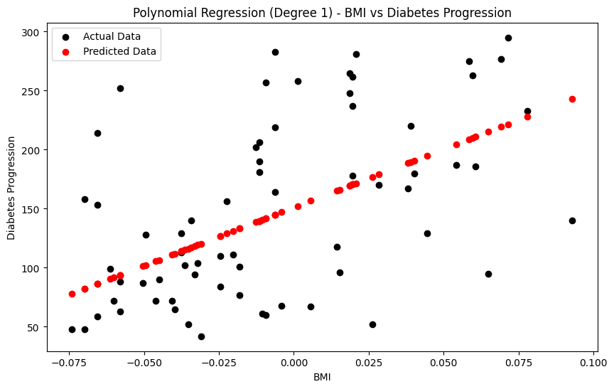

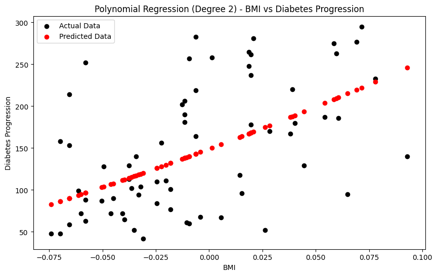

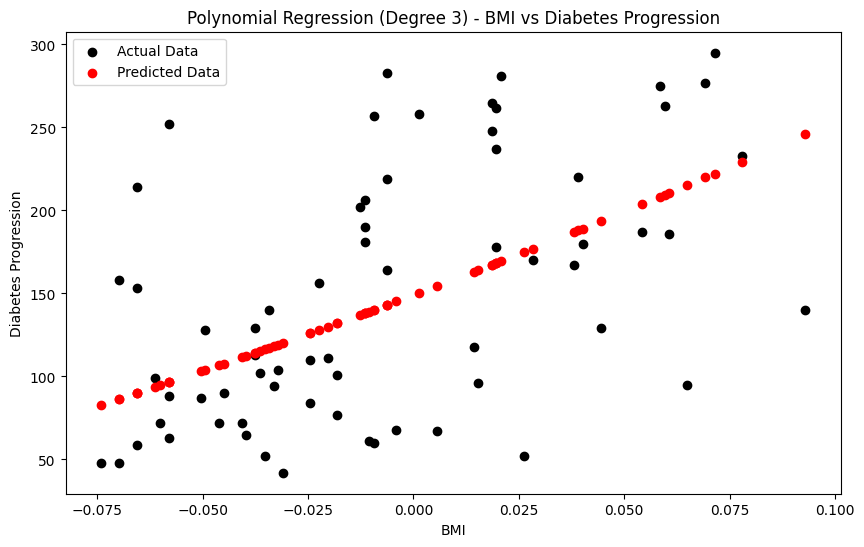

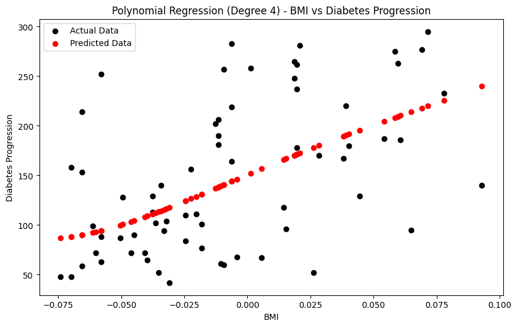

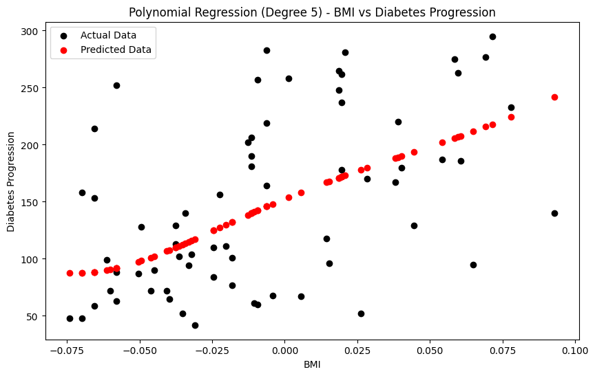

```
   Degree  Train R-squared  Validation R-squared  Test R-squared  Train MAE  \
0       0         0.000000             -0.008055       -0.005042  66.713922
1       1         0.365765              0.302543        0.260573  51.951199
2       2         0.366837              0.296223        0.259067  51.883089
3       3         0.366840              0.297015        0.259174  51.878337
4       4         0.368665              0.263194        0.268002  51.772629
5       5         0.369675              0.297578        0.267444  51.760799

   Validation MAE   Test MAE  Train MAPE  Validation MAPE  Test MAPE
0       62.042954  66.452543    0.637647         0.579577   0.643320
1       48.270702  52.880785    0.482628         0.420456   0.455497
2       48.273028  53.084912    0.482172         0.419024   0.458193
3       48.235127  53.079599    0.482086         0.418775   0.458161
4       48.367440  52.706821    0.479762         0.414836   0.454696
5       47.348851  52.501378    0.479192         0.407376   0.452032
```

```python
from sklearn.preprocessing import PolynomialFeatures
from sklearn.linear_model import LinearRegression
from sklearn.metrics import r2_score, mean_absolute_error, mean_absolute_percentage_error
import matplotlib.pyplot as plt
# Create an array to store results
degrees = np.arange(6)
train_r2_scores = []
val_r2_scores = []
test_r2_scores = []
train_maes = []
val_maes = []
test_maes = []
train_mapes = []
val_mapes = []
test_mapes = []
# Loop through polynomial degrees
for degree in degrees:
    # Create polynomial features
    poly = PolynomialFeatures(degree=degree)
    X_train_poly = poly.fit_transform(X_train[['bmi']])
    X_val_poly = poly.transform(X_val[['bmi']])
    X_test_poly = poly.transform(X_test[['bmi']])
    # Fit linear regression model
    model = LinearRegression()
    model.fit(X_train_poly, y_train)
    # Predictions
    y_train_pred = model.predict(X_train_poly)
    y_val_pred = model.predict(X_val_poly)
    y_test_pred = model.predict(X_test_poly)
    # Evaluate R-squared
    train_r2 = r2_score(y_train, y_train_pred)
    val_r2 = r2_score(y_val, y_val_pred)
    test_r2 = r2_score(y_test, y_test_pred)
    # Evaluate MAE
    train_mae = mean_absolute_error(y_train, y_train_pred)
    val_mae = mean_absolute_error(y_val, y_val_pred)
    test_mae = mean_absolute_error(y_test, y_test_pred)
    # Evaluate MAPE
    train_mape = mean_absolute_percentage_error(y_train, y_train_pred)
    val_mape = mean_absolute_percentage_error(y_val, y_val_pred)
    test_mape = mean_absolute_percentage_error(y_test, y_test_pred)
    # Append results to arrays
    train_r2_scores.append(train_r2)
    val_r2_scores.append(val_r2)
    test_r2_scores.append(test_r2)
    train_maes.append(train_mae)
    val_maes.append(val_mae)
    test_maes.append(test_mae)
    train_mapes.append(train_mape)
    val_mapes.append(val_mape)
    test_mapes.append(test_mape)
    # Plot predictions for visualization
    plt.figure(figsize=(10, 6))
    plt.scatter(X_test['bmi'], y_test, color='black', label='Actual Data')
    plt.scatter(X_test['bmi'], y_test_pred, color='red', label='Predicted Data')
    plt.title(f'Polynomial Regression (Degree {degree}) - BMI vs Diabetes Progression')
    plt.xlabel('BMI')
    plt.ylabel('Diabetes Progression')
    plt.legend()
    plt.show()
# Display results
results_df = pd.DataFrame({
    'Degree': degrees,
    'Train R-squared': train_r2_scores,
    'Validation R-squared': val_r2_scores,
    'Test R-squared': test_r2_scores,
    'Train MAE': train_maes,
    'Validation MAE': val_maes,
    'Test MAE': test_maes,
    'Train MAPE': train_mapes,
    'Validation MAPE': val_mapes,
    'Test MAPE': test_mapes,
})
print(results_df)
```

**Comparing the six models using the training and validation data:**

Report R-squared, MAPE and MAE. You should have 6 values per model

```python
# Display R-squared, MAPE, and MAE for each model
print("Comparison of Models using Training and Validation Data:")
for degree in degrees:
    print(f"\nModel with Degree {degree}:")
    print(f"Train R-squared: {results_df.loc[results_df['Degree'] == degree, 'Train R-squared'].values[0]:.4f}")
    print(f"Validation R-squared: {results_df.loc[results_df['Degree'] == degree, 'Validation R-squared'].values[0]:.4f}")
    print(f"Train MAE: {results_df.loc[results_df['Degree'] == degree, 'Train MAE'].values[0]:.4f}")
    print(f"Validation MAE: {results_df.loc[results_df['Degree'] == degree, 'Validation MAE'].values[0]:.4f}")
    print(f"Train MAPE: {results_df.loc[results_df['Degree'] == degree, 'Train MAPE'].values[0]:.4f}")
    print(f"Validation MAPE: {results_df.loc[results_df['Degree'] == degree, 'Validation MAPE'].values[0]:.4f}")
    print("-" * 40)
```

```
Comparison of Models using Training and Validation Data:

Model with Degree 0:
Train R-squared: 0.0000
Validation R-squared: -0.0081
Train MAE: 66.7139
Validation MAE: 62.0430
Train MAPE: 0.6376
Validation MAPE: 0.5796
----------------------------------------

Model with Degree 1:
Train R-squared: 0.3658
Validation R-squared: 0.3025
Train MAE: 51.9512
Validation MAE: 48.2707
Train MAPE: 0.4826
Validation MAPE: 0.4205
----------------------------------------

Model with Degree 2:
Train R-squared: 0.3668
Validation R-squared: 0.2962
Train MAE: 51.8831
Validation MAE: 48.2730
Train MAPE: 0.4822
Validation MAPE: 0.4190
----------------------------------------

Model with Degree 3:
Train R-squared: 0.3668
Validation R-squared: 0.2970
Train MAE: 51.8783
Validation MAE: 48.2351
Train MAPE: 0.4821
Validation MAPE: 0.4188
----------------------------------------

Model with Degree 4:
Train R-squared: 0.3687
Validation R-squared: 0.2632
Train MAE: 51.7726
Validation MAE: 48.3674
Train MAPE: 0.4798
Validation MAPE: 0.4148
----------------------------------------

Model with Degree 5:
Train R-squared: 0.3697
Validation R-squared: 0.2976
Train MAE: 51.7608
Validation MAE: 47.3489
Train MAPE: 0.4792
Validation MAPE: 0.4074
----------------------------------------
```

**Run the chosen model on the test set, and report R-Squared, MSE and MAE for it**

```python
from sklearn.metrics import mean_squared_error
# Identify the best model based on validation R-squared
best_model_degree = results_df.loc[results_df['Validation R-squared'].idxmax(), 'Degree']
# Extract metrics for the best model
best_model_metrics = results_df[results_df['Degree'] == best_model_degree].iloc[0]
# Display the best model metrics
print(f"Best Model (Degree {best_model_degree}):")
print(f"Train R-squared: {best_model_metrics['Train R-squared']:.4f}")
print(f"Validation R-squared: {best_model_metrics['Validation R-squared']:.4f}")
print(f"Train MAE: {best_model_metrics['Train MAE']:.4f}")
print(f"Validation MAE: {best_model_metrics['Validation MAE']:.4f}")
print(f"Train MAPE: {best_model_metrics['Train MAPE']:.4f}")
print(f"Validation MAPE: {best_model_metrics['Validation MAPE']:.4f}")
# Run the best model on the test set
best_model = LinearRegression()
poly = PolynomialFeatures(degree=best_model_degree)
X_train_poly = poly.fit_transform(X_train[['bmi']])
X_test_poly = poly.transform(X_test[['bmi']])
best_model.fit(X_train_poly, y_train)
y_test_pred = best_model.predict(X_test_poly)
# Evaluate the best model on the test set
test_r2 = r2_score(y_test, y_test_pred)
test_mse = mean_squared_error(y_test, y_test_pred)
test_mae = mean_absolute_error(y_test, y_test_pred)
# Display results on the test set
print("\nResults on the Test Set:")
print(f"Test R-squared: {test_r2:.4f}")
print(f"Test MSE: {test_mse:.4f}")
print(f"Test MAE: {test_mae:.4f}")
```

```
Best Model (Degree 1):
Train R-squared: 0.3658
Validation R-squared: 0.3025
Train MAE: 51.9512
Validation MAE: 48.2707
Train MAPE: 0.4826
Validation MAPE: 0.4205

Results on the Test Set:
Test R-squared: 0.2606
Test MSE: 4198.4496
Test MAE: 52.8808
```

**Graph of the train, validation and test datapoints, and the fit of the chosen model over each of them**

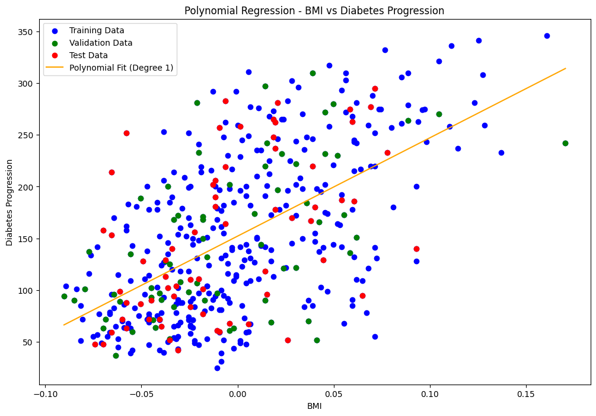

```python
import numpy as np
import pandas as pd
import matplotlib.pyplot as plt
from sklearn.datasets import load_diabetes
from sklearn.model_selection import train_test_split
from sklearn.preprocessing import PolynomialFeatures
from sklearn.linear_model import LinearRegression
from sklearn.metrics import r2_score, mean_squared_error, mean_absolute_error
diabetes = load_diabetes()
df = pd.DataFrame(data=diabetes.data, columns=diabetes.feature_names)
df['Target'] = diabetes.target
X = df[['bmi']]
y = df['Target']
X_train, X_temp, y_train, y_temp = train_test_split(X, y, test_size=0.3, random_state=42)
X_val, X_test, y_val, y_test = train_test_split(X_temp, y_temp, test_size=0.5, random_state=42)
degrees = np.arange(6)
train_r2_scores = []
val_r2_scores = []
test_r2_scores = []
train_maes = []
val_maes = []
test_maes = []
for degree in degrees:
    poly = PolynomialFeatures(degree=degree)
    X_train_poly = poly.fit_transform(X_train[['bmi']])
    X_val_poly = poly.transform(X_val[['bmi']])
    X_test_poly = poly.transform(X_test[['bmi']])
    model = LinearRegression()
    model.fit(X_train_poly, y_train)
    y_train_pred = model.predict(X_train_poly)
    y_val_pred = model.predict(X_val_poly)
    y_test_pred = model.predict(X_test_poly)
    train_r2 = r2_score(y_train, y_train_pred)
    val_r2 = r2_score(y_val, y_val_pred)
    test_r2 = r2_score(y_test, y_test_pred)
    train_mae = mean_absolute_error(y_train, y_train_pred)
    val_mae = mean_absolute_error(y_val, y_val_pred)
    test_mae = mean_absolute_error(y_test, y_test_pred)
    train_r2_scores.append(train_r2)
    val_r2_scores.append(val_r2)
    test_r2_scores.append(test_r2)
    train_maes.append(train_mae)
    val_maes.append(val_mae)
    test_maes.append(test_mae)
best_model_degree = np.argmax(val_r2_scores)
best_degree = degrees[best_model_degree]
poly = PolynomialFeatures(degree=best_degree)
X_poly = poly.fit_transform(X[['bmi']])
X_test_poly = poly.transform(X_test[['bmi']])
model = LinearRegression()
model.fit(X_poly, y)
y_pred = model.predict(X_poly)
y_test_pred = model.predict(X_test_poly)
plt.figure(figsize=(12, 8))
plt.scatter(X['bmi'], y, label='Training Data', color='blue')
plt.scatter(X_val['bmi'], y_val, label='Validation Data', color='green')
plt.scatter(X_test['bmi'], y_test, label='Test Data', color='red')
sort_idx = np.argsort(X['bmi'])
plt.plot(X['bmi'].values[sort_idx], y_pred[sort_idx], label=f'Polynomial Fit (Degree {best_degree})', color='orange')
plt.title('Polynomial Regression - BMI vs Diabetes Progression')
plt.xlabel('BMI')
plt.ylabel('Diabetes Progression')
plt.legend()
plt.show()
```

Comparing the six models using the training and validation data and choose the best model based on quantitative reasoning. We will then write down the equation of the best model and manually calculate the expected diabetes progression for a BMI value of our choice, comparing it to the model's prediction for that value.

```python
import numpy as np
import pandas as pd
from sklearn.datasets import load_diabetes
from sklearn.model_selection import train_test_split
from sklearn.preprocessing import PolynomialFeatures
from sklearn.linear_model import LinearRegression
from sklearn.metrics import r2_score, mean_squared_error, mean_absolute_error
diabetes = load_diabetes()
df = pd.DataFrame(data=diabetes.data, columns=diabetes.feature_names)
df['Target'] = diabetes.target
X = df[['bmi']]
y = df['Target']
X_train, X_temp, y_train, y_temp = train_test_split(X, y, test_size=0.3, random_state=42)
X_val, X_test, y_val, y_test = train_test_split(X_temp, y_temp, test_size=0.5, random_state=42)
degrees = np.arange(6)
train_r2_scores = []
val_r2_scores = []
train_maes = []
val_maes = []
for degree in degrees:
    poly = PolynomialFeatures(degree=degree)
    X_train_poly = poly.fit_transform(X_train[['bmi']])
    X_val_poly = poly.transform(X_val[['bmi']])
    model = LinearRegression()
    model.fit(X_train_poly, y_train)
    y_train_pred = model.predict(X_train_poly)
    y_val_pred = model.predict(X_val_poly)
    train_r2 = r2_score(y_train, y_train_pred)
    val_r2 = r2_score(y_val, y_val_pred)
    train_mae = mean_absolute_error(y_train, y_train_pred)
    val_mae = mean_absolute_error(y_val, y_val_pred)
    train_r2_scores.append(train_r2)
    val_r2_scores.append(val_r2)
    train_maes.append(train_mae)
    val_maes.append(val_mae)
best_model_degree = np.argmax(val_r2_scores)
best_degree = degrees[best_model_degree]
print(f"Best Model (Degree {best_degree}):")
print(f"Train R-squared: {train_r2_scores[best_model_degree]:.4f}")
print(f"Validation R-squared: {val_r2_scores[best_model_degree]:.4f}")
print(f"Train MAE: {train_maes[best_model_degree]:.4f}")
print(f"Validation MAE: {val_maes[best_model_degree]:.4f}")
poly = PolynomialFeatures(degree=best_degree)
X_poly = poly.fit_transform(X)
best_model = LinearRegression()
best_model.fit(X_poly, y)
equation = f"Diabetes Progression = {best_model.intercept_:.2f}"
for i in range(1, best_degree + 1):
    equation += f" + {best_model.coef_[i]:.2f} * (bmi^{i})"
print("\nEquation of the Best Model:")
print(equation)
chosen_bmi = 25.0
expected_progression_manual = best_model.intercept_
for i in range(1, best_degree + 1):
    expected_progression_manual += best_model.coef_[i] * (chosen_bmi ** i)
chosen_bmi_poly = poly.transform(np.array([[chosen_bmi]]))
expected_progression_model = best_model.predict(chosen_bmi_poly)[0]
print("\nComparison of Manual Calculation and Model Prediction:")
print(f"Expected Progression (Manual Calculation): {expected_progression_manual:.2f}")
print(f"Expected Progression (Model Prediction): {expected_progression_model:.2f}")
```

```
Best Model (Degree 1):
Train R-squared: 0.3658
Validation R-squared: 0.3025
Train MAE: 51.9512
Validation MAE: 48.2707

Equation of the Best Model:
Diabetes Progression = 152.13 + 949.44 * (bmi^1)

Comparison of Manual Calculation and Model Prediction:
Expected Progression (Manual Calculation): 23888.01
Expected Progression (Model Prediction): 23888.01
```

Let's calculate the number of trainable parameters for each of the six polynomial regression models using the get_feature_names_out()

```python
from sklearn.preprocessing import PolynomialFeatures
num_parameters_list = []
for degree in degrees:
    poly = PolynomialFeatures(degree=degree)
    X_train_poly = poly.fit_transform(X_train[['bmi']])
    feature_names = poly.get_feature_names_out(['bmi'])
    num_parameters = len(feature_names)
    num_parameters_list.append(num_parameters)
for i, degree in enumerate(degrees):
    print(f"Number of trainable parameters for model with degree {degree}: {num_parameters_list[i]}")
```

```
Number of trainable parameters for model with degree 0: 1
Number of trainable parameters for model with degree 1: 2
Number of trainable parameters for model with degree 2: 3
Number of trainable parameters for model with degree 3: 4
Number of trainable parameters for model with degree 4: 5
Number of trainable parameters for model with degree 5: 6
```

**Explanation**

1. **For a univariate polynomial regression with degree d, we have d + 1 terms (including the constant term) for each feature.**
2. **In our case, there is only one feature (BMI), so the total number of parameters is (d + 1).**
3. **We multiply this by the number of features to get the total number of trainable parameters.**

**Therefore above values represent the coefficients (weights) assigned to each term in the polynomial equation, including the intercept term**